# Tugas Pertemuan 5

Rifqi Rustu Andana - G1401211067

```r
library(ggplot2)
library(tsibble)
library(tseries)
library(MASS)
```

# Input data

```r
datazamboanga<- read.csv("https://raw.githubusercontent.com/Tuyye/mpdw/main/Tugas/Tugas1/Suhu%20Zamboanga.csv" )
datazamboanga
```

| Periode | Suhu |
| --- | --- |
| 1 | 27.51 |
| 2 | 27.85 |
| 3 | 28.76 |
| 4 | 29.11 |
| 5 | 29.63 |
| 6 | 29.40 |
| 7 | 28.85 |
| 8 | 28.72 |
| 9 | 29.24 |
| 10 | 29.11 |

[output cut: 134 more lines]

# Data FULL

### Ubah data ke ts

```r
datazamboanga.ts <- ts(datazamboanga$Suhu)
```

### Membuat plot time series

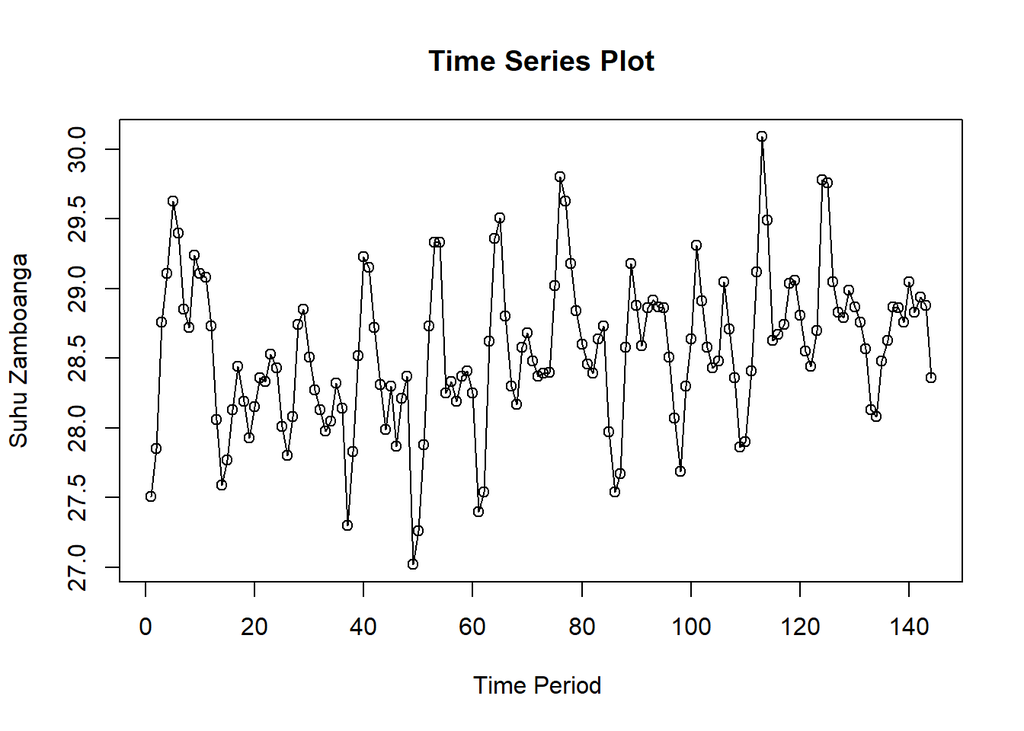

```r
ts.plot(datazamboanga.ts, xlab="Time Period ", ylab="Suhu Zamboanga",
        main = "Time Series Plot")
points(datazamboanga.ts)
```

### Plot ACF

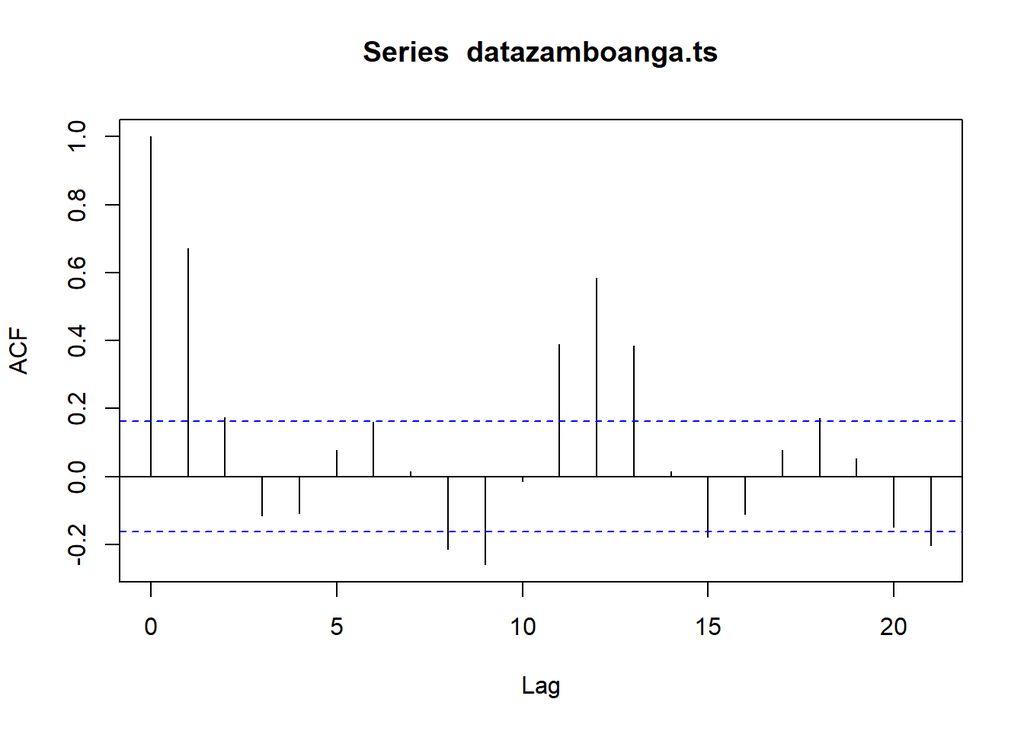

```r
acf(datazamboanga.ts)
```

Berdasarkan plot ACF, terlihat bahwa plot ACF pada data tersebut cenderung *tails off* dan membentuk gelombang sinus.

### Uji ADF

```r
tseries::adf.test(datazamboanga.ts)
```

```
##
##  Augmented Dickey-Fuller Test
##
## data:  datazamboanga.ts
## Dickey-Fuller = -4.9594, Lag order = 5, p-value = 0.01
## alternative hypothesis: stationary
```

$H_0$ : Data tidak stasioner dalam rataan

$H_1$ : Data stasioner dalam rataan

Berdasarkan uji ADF tersebut, didapat *p-value* sebesar 0.01 yang lebih kecil dari taraf nyata 5% sehingga tolak $H_0$ dan menandakan bahwa data stasioner dalam rataan. Hal ini sesuai dengan hasil eksplorasi menggunakan plot time series dan plot ACF.

### Plot Box-Cox

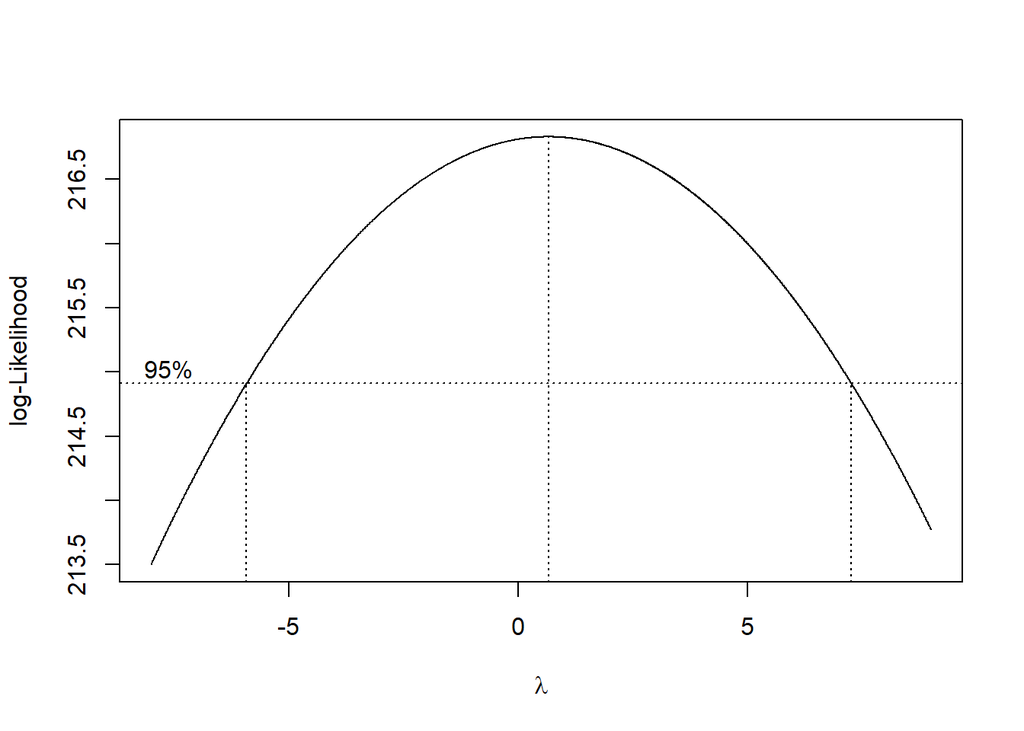

```r
index <- seq(1:144)
bc = boxcox(datazamboanga.ts~index, lambda = seq(-8,9,by=0.01))
```

```r
#Nilai Rounded Lambda
lambda <- bc$x[which.max(bc$y)]
lambda
```

```
## [1] 0.66
```

```r
#SK
bc$x[bc$y > max(bc$y) - 1/2 * qchisq(.95,1)]
```

```
##    [1] -5.91 -5.90 -5.89 -5.88 -5.87 -5.86 -5.85 -5.84 -5.83 -5.82 -5.81 -5.80
##   [13] -5.79 -5.78 -5.77 -5.76 -5.75 -5.74 -5.73 -5.72 -5.71 -5.70 -5.69 -5.68
##   [25] -5.67 -5.66 -5.65 -5.64 -5.63 -5.62 -5.61 -5.60 -5.59 -5.58 -5.57 -5.56
##   [37] -5.55 -5.54 -5.53 -5.52 -5.51 -5.50 -5.49 -5.48 -5.47 -5.46 -5.45 -5.44
##   [49] -5.43 -5.42 -5.41 -5.40 -5.39 -5.38 -5.37 -5.36 -5.35 -5.34 -5.33 -5.32
##   [61] -5.31 -5.30 -5.29 -5.28 -5.27 -5.26 -5.25 -5.24 -5.23 -5.22 -5.21 -5.20
##   [73] -5.19 -5.18 -5.17 -5.16 -5.15 -5.14 -5.13 -5.12 -5.11 -5.10 -5.09 -5.08
##   [85] -5.07 -5.06 -5.05 -5.04 -5.03 -5.02 -5.01 -5.00 -4.99 -4.98 -4.97 -4.96
##   [97] -4.95 -4.94 -4.93 -4.92 -4.91 -4.90 -4.89 -4.88 -4.87 -4.86 -4.85 -4.84
##  [109] -4.83 -4.82 -4.81 -4.80 -4.79 -4.78 -4.77 -4.76 -4.75 -4.74 -4.73 -4.72
##  [121] -4.71 -4.70 -4.69 -4.68 -4.67 -4.66 -4.65 -4.64 -4.63 -4.62 -4.61 -4.60
##  [133] -4.59 -4.58 -4.57 -4.56 -4.55 -4.54 -4.53 -4.52 -4.51 -4.50 -4.49 -4.48
##  [145] -4.47 -4.46 -4.45 -4.44 -4.43 -4.42 -4.41 -4.40 -4.39 -4.38 -4.37 -4.36
##  [157] -4.35 -4.34 -4.33 -4.32 -4.31 -4.30 -4.29 -4.28 -4.27 -4.26 -4.25 -4.24
##  [169] -4.23 -4.22 -4.21 -4.20 -4.19 -4.18 -4.17 -4.16 -4.15 -4.14 -4.13 -4.12
```

[output cut: 95 more lines]

Kesimpulan: Maka data tersebut stasioner dalam rataan dan ragam

# Bagian 1

```r
datazamboanga.ts1 <- datazamboanga$Suhu[1:48] |> ts()
mean(datazamboanga.ts1)
```

```
## [1] 28.38708
```

```r
var(datazamboanga.ts1)
```

```
## [1] 0.2708211
```

### Membuat plot time series

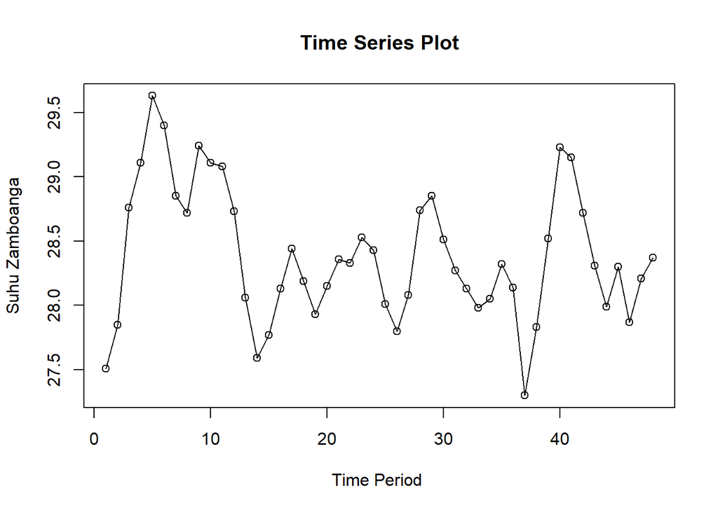

```r
ts.plot(datazamboanga.ts1, xlab="Time Period ", ylab="Suhu Zamboanga",
        main = "Time Series Plot")
points(datazamboanga.ts1)
```

### Plot ACF

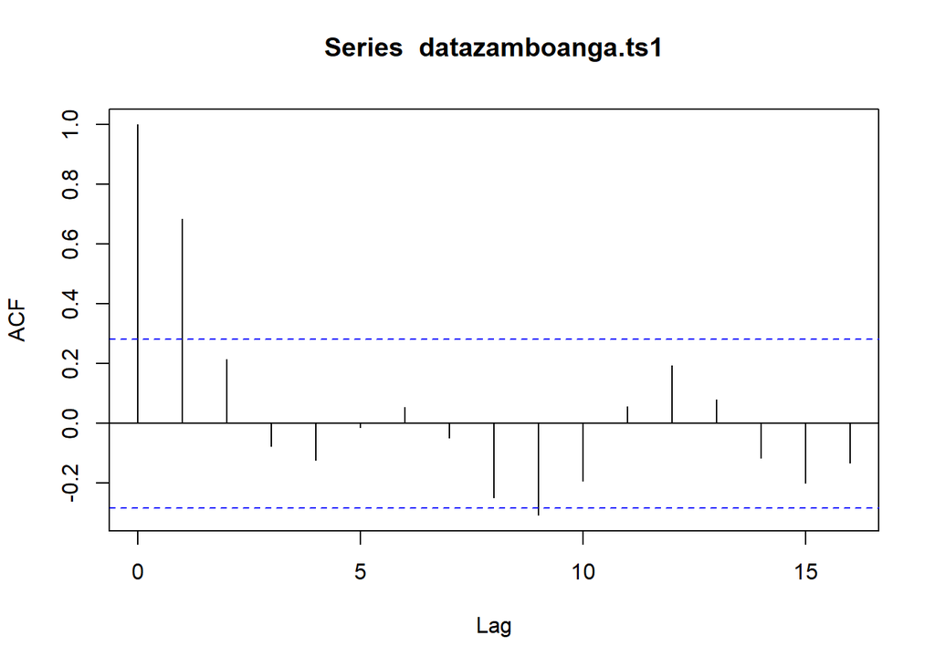

```r
acf(datazamboanga.ts1)
```

Berdasarkan plot ACF, terlihat bahwa plot ACF pada data tersebut cenderung *tails off* dan membentuk gelombang sinus.

### Uji ADF

```r
tseries::adf.test(datazamboanga.ts1)
```

```
##
##  Augmented Dickey-Fuller Test
##
## data:  datazamboanga.ts1
## Dickey-Fuller = -2.8155, Lag order = 3, p-value = 0.2484
## alternative hypothesis: stationary
```

$H_0$ : Data tidak stasioner dalam rataan

$H_1$ : Data stasioner dalam rataan

### Plot Box-Cox

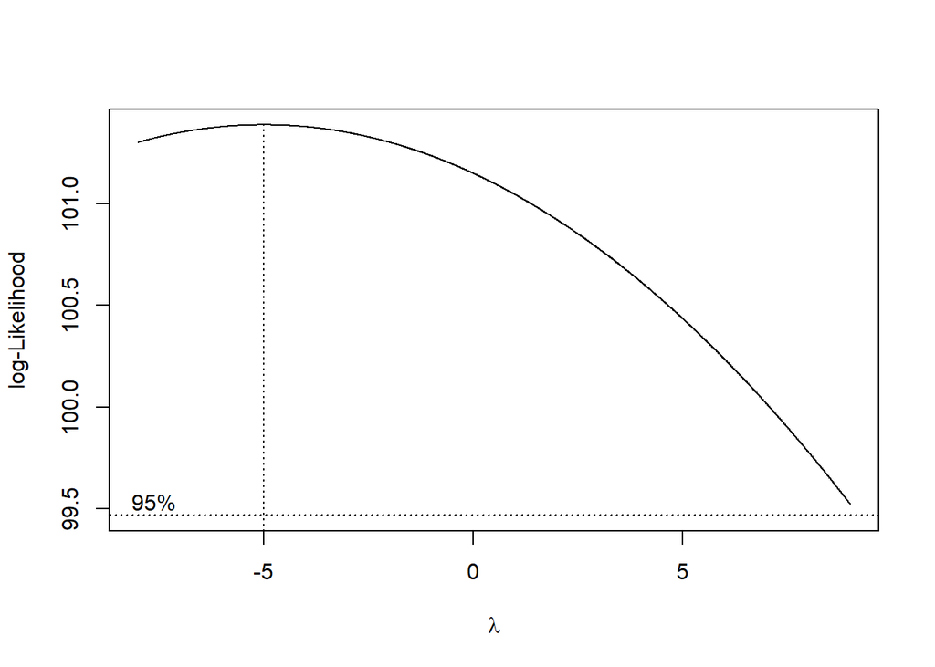

```r
index.1 <- seq(1:48)
bc.1 = boxcox(datazamboanga.ts1~index.1, lambda = seq(-8,9,by=0.01))
```

```r
#Nilai Rounded Lambda
lambda.1 <- bc.1$x[which.max(bc.1$y)]
lambda.1
```

```
## [1] -5
```

```r
#SK
bc.1$x[bc.1$y > max(bc.1$y) - 1/2 * qchisq(.95,1)]
```

```
##    [1] -8.00 -7.99 -7.98 -7.97 -7.96 -7.95 -7.94 -7.93 -7.92 -7.91 -7.90 -7.89
##   [13] -7.88 -7.87 -7.86 -7.85 -7.84 -7.83 -7.82 -7.81 -7.80 -7.79 -7.78 -7.77
##   [25] -7.76 -7.75 -7.74 -7.73 -7.72 -7.71 -7.70 -7.69 -7.68 -7.67 -7.66 -7.65
##   [37] -7.64 -7.63 -7.62 -7.61 -7.60 -7.59 -7.58 -7.57 -7.56 -7.55 -7.54 -7.53
##   [49] -7.52 -7.51 -7.50 -7.49 -7.48 -7.47 -7.46 -7.45 -7.44 -7.43 -7.42 -7.41
##   [61] -7.40 -7.39 -7.38 -7.37 -7.36 -7.35 -7.34 -7.33 -7.32 -7.31 -7.30 -7.29
##   [73] -7.28 -7.27 -7.26 -7.25 -7.24 -7.23 -7.22 -7.21 -7.20 -7.19 -7.18 -7.17
##   [85] -7.16 -7.15 -7.14 -7.13 -7.12 -7.11 -7.10 -7.09 -7.08 -7.07 -7.06 -7.05
##   [97] -7.04 -7.03 -7.02 -7.01 -7.00 -6.99 -6.98 -6.97 -6.96 -6.95 -6.94 -6.93
##  [109] -6.92 -6.91 -6.90 -6.89 -6.88 -6.87 -6.86 -6.85 -6.84 -6.83 -6.82 -6.81
##  [121] -6.80 -6.79 -6.78 -6.77 -6.76 -6.75 -6.74 -6.73 -6.72 -6.71 -6.70 -6.69
##  [133] -6.68 -6.67 -6.66 -6.65 -6.64 -6.63 -6.62 -6.61 -6.60 -6.59 -6.58 -6.57
##  [145] -6.56 -6.55 -6.54 -6.53 -6.52 -6.51 -6.50 -6.49 -6.48 -6.47 -6.46 -6.45
##  [157] -6.44 -6.43 -6.42 -6.41 -6.40 -6.39 -6.38 -6.37 -6.36 -6.35 -6.34 -6.33
##  [169] -6.32 -6.31 -6.30 -6.29 -6.28 -6.27 -6.26 -6.25 -6.24 -6.23 -6.22 -6.21
```

[output cut: 127 more lines]

# Bagian 2

```r
datazamboanga.ts2 <- datazamboanga$Suhu[49:144] |> ts()
mean(datazamboanga.ts2)
```

```
## [1] 28.63521
```

```r
var(datazamboanga.ts2)
```

```
## [1] 0.3001179
```

### Membuat plot time series

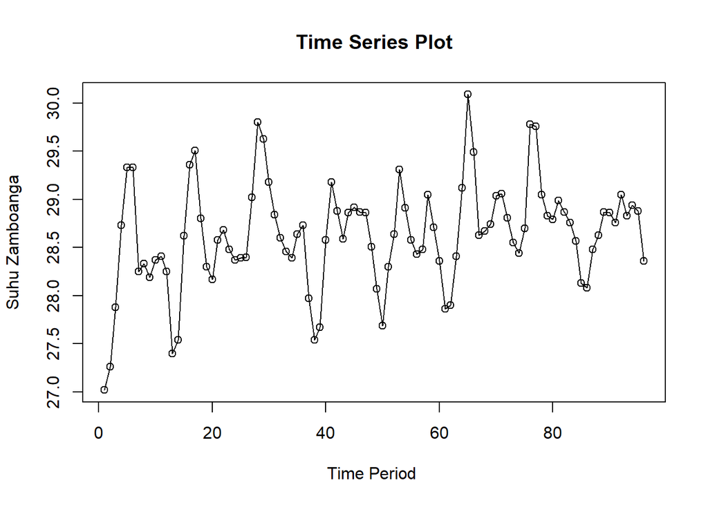

```r
ts.plot(datazamboanga.ts2, xlab="Time Period ", ylab="Suhu Zamboanga",
        main = "Time Series Plot")
points(datazamboanga.ts2)
```

### Plot ACF

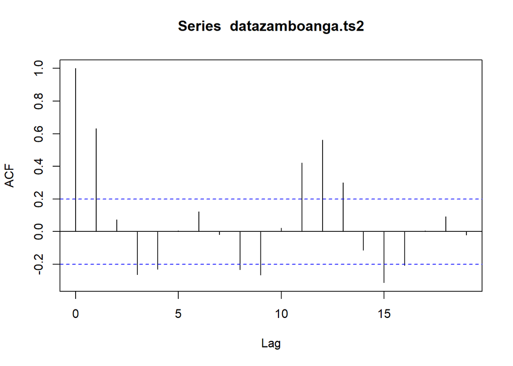

```r
acf(datazamboanga.ts2)
```

Berdasarkan plot ACF, terlihat bahwa plot ACF pada data tersebut cenderung *tails off* dan membentuk gelombang sinus.

### Uji ADF

```r
tseries::adf.test(datazamboanga.ts2)
```

```
##
##  Augmented Dickey-Fuller Test
##
## data:  datazamboanga.ts2
## Dickey-Fuller = -3.9551, Lag order = 4, p-value = 0.01458
## alternative hypothesis: stationary
```

$H_0$ : Data tidak stasioner dalam rataan

$H_1$ : Data stasioner dalam rataan

Berdasarkan uji ADF tersebut, didapat *p-value* sebesar 0.01458 yang lebih kecil dari taraf nyata 5% sehingga tolak $H_0$ dan menandakan bahwa data stasioner dalam rataan. Hal ini sesuai dengan hasil eksplorasi menggunakan plot time series dan plot ACF.

### Plot Box-Cox

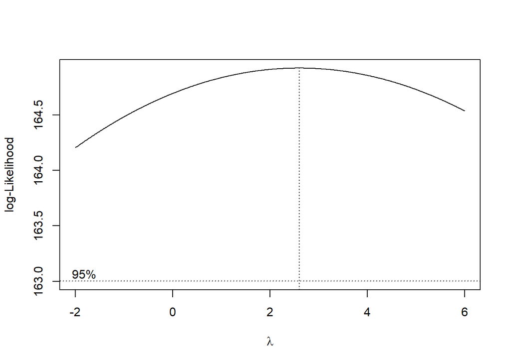

```r
index.2 <- seq(49:144)
bc.2 = boxcox(datazamboanga.ts2~index.2, lambda = seq(-2,6,by=0.01))
```

```r
#Nilai Rounded Lambda
lambda.2 <- bc.2$x[which.max(bc.2$y)]
lambda.2
```

```
## [1] 2.6
```

```r
#SK
bc.2$x[bc.2$y > max(bc.2$y) - 1/2 * qchisq(.95,1)]
```

```
##   [1] -2.00 -1.99 -1.98 -1.97 -1.96 -1.95 -1.94 -1.93 -1.92 -1.91 -1.90 -1.89
##  [13] -1.88 -1.87 -1.86 -1.85 -1.84 -1.83 -1.82 -1.81 -1.80 -1.79 -1.78 -1.77
##  [25] -1.76 -1.75 -1.74 -1.73 -1.72 -1.71 -1.70 -1.69 -1.68 -1.67 -1.66 -1.65
##  [37] -1.64 -1.63 -1.62 -1.61 -1.60 -1.59 -1.58 -1.57 -1.56 -1.55 -1.54 -1.53
##  [49] -1.52 -1.51 -1.50 -1.49 -1.48 -1.47 -1.46 -1.45 -1.44 -1.43 -1.42 -1.41
##  [61] -1.40 -1.39 -1.38 -1.37 -1.36 -1.35 -1.34 -1.33 -1.32 -1.31 -1.30 -1.29
##  [73] -1.28 -1.27 -1.26 -1.25 -1.24 -1.23 -1.22 -1.21 -1.20 -1.19 -1.18 -1.17
##  [85] -1.16 -1.15 -1.14 -1.13 -1.12 -1.11 -1.10 -1.09 -1.08 -1.07 -1.06 -1.05
##  [97] -1.04 -1.03 -1.02 -1.01 -1.00 -0.99 -0.98 -0.97 -0.96 -0.95 -0.94 -0.93
## [109] -0.92 -0.91 -0.90 -0.89 -0.88 -0.87 -0.86 -0.85 -0.84 -0.83 -0.82 -0.81
## [121] -0.80 -0.79 -0.78 -0.77 -0.76 -0.75 -0.74 -0.73 -0.72 -0.71 -0.70 -0.69
## [133] -0.68 -0.67 -0.66 -0.65 -0.64 -0.63 -0.62 -0.61 -0.60 -0.59 -0.58 -0.57
## [145] -0.56 -0.55 -0.54 -0.53 -0.52 -0.51 -0.50 -0.49 -0.48 -0.47 -0.46 -0.45
## [157] -0.44 -0.43 -0.42 -0.41 -0.40 -0.39 -0.38 -0.37 -0.36 -0.35 -0.34 -0.33
## [169] -0.32 -0.31 -0.30 -0.29 -0.28 -0.27 -0.26 -0.25 -0.24 -0.23 -0.22 -0.21
```

[output cut: 52 more lines]

Gambar di atas menunjukkan nilai *rounded value* ($\lambda$) optimum sebesar **2.6** dan pada selang kepercayaan 95% nilai memiliki batas bawah **-2.00** dan batas atas **6.00**. Selang tersebut memuat nilai satu sehingga dapat dikatakan bahwa data bangkitan stasioner dalam ragam.

Kesimpulan partisi 2: Maka data tersebut stasioner dalam rataan dan ragam